# mlVAR Technical Report: Multilevel Vector Autoregression in Saqrlab

Saqrlab

2026-02-27

# 1. Overview

`mlvar()` estimates three psychological networks from Experience Sampling Method (ESM) or Ecological Momentary Assessment (EMA) panel data:

1. **Temporal network** (directed): lagged regression coefficients showing how each variable at time *t-1* predicts every variable at time *t*
2. **Contemporaneous network** (undirected): partial correlations among within-person residuals after removing temporal effects
3. **Between-subjects network** (undirected): partial correlations among person-level means

The implementation uses within-person centering with fixed-effects OLS for the temporal model and EBIC-selected graphical LASSO for the contemporaneous and between-subjects networks. No new package dependencies are required — it reuses the existing GLASSO pipeline in Saqrlab (`glasso` is already in Imports).

# 2. Algorithm

## 2.1 Data Preparation

Data is sorted by `(id, day, beep)`. Rows with NA in any model variable are dropped. Variable columns are coerced to numeric.

## 2.2 Lag-Pair Construction

Valid observation pairs $(t-\text{lag}, t)$ are formed subject to three constraints:

- Same person: `id[t] == id[t-lag]`
- Same day (if provided): `day[t] == day[t-lag]`
- Consecutive beep (if provided): `beep[t] - beep[t-lag] == lag`

This is fully vectorized — no row-by-row iteration.

## 2.3 Within-Person Centering

Both outcome ($Y$) and predictor ($X$) matrices are person-mean centered using `ave(x, id, FUN = mean)`. This absorbs the random intercept, making OLS equivalent to the fixed-effects panel estimator. When `standardize = TRUE`, centered variables are divided by their pooled standard deviation.

## 2.4 Temporal OLS

For each outcome variable $k$, the model is:

$$Y_{c,k} = X_c \beta_k +
\varepsilon_k$$

fitted via `lm.fit()` (no intercept, since centering absorbed it). Standard errors are corrected for the absorbed person effects:

$$df_{\text{correct}} = n_{\text{obs}} - d
- n_{\text{subjects}}$$
$$SE_{\text{correct}} = SE_{\text{OLS}} \times
\sqrt{\frac{df_{\text{OLS}}}{df_{\text{correct}}}}$$

## 2.5 Contemporaneous Network

The correlation matrix of OLS residuals is fed into the existing EBIC-GLASSO pipeline (`.compute_lambda_path()` $\rightarrow$ `.select_ebic()` $\rightarrow$ `.precision_to_pcor()`), producing a sparse partial correlation matrix.

## 2.6 Between-Subjects Network

Person means are computed via `aggregate()`. Their correlation matrix goes through the same GLASSO pipeline. A guard returns a zero matrix when $n_{\text{subjects}} < d + 1$.

# 3. Function Signature

```r
mlvar(data, vars, id, day = NULL, beep = NULL,
      lag = 1L, standardize = TRUE, gamma = 0.5, nlambda = 100L)
```

| Parameter | Description |
| --- | --- |
| `data` | Data frame with panel data |
| `vars` | Character vector of variable column names |
| `id` | Person-ID column name |
| `day` | Day/session column (optional) |
| `beep` | Measurement-occasion column (optional) |
| `lag` | Lag order (default 1) |
| `standardize` | Standardize after centering (default TRUE) |
| `gamma` | EBIC hyperparameter for GLASSO (default 0.5) |
| `nlambda` | Number of lambda values (default 100) |

Returns an S3 object of class `"mlvar_result"` with `print()` and `summary()` methods.

# 4. Validation Against mlVAR Package

We validated our implementation against `mlVAR::mlVAR()` (Epskamp et al.) across 25 random datasets generated by `simulate_data("mlvar")`.

## 4.1 Equivalence Configuration

To match our fixed-effects OLS approach, we use:

```r
mlVAR::mlVAR(..., estimator = "lmer", temporal = "fixed",
             contemporaneous = "fixed", scale = FALSE)
```

## 4.2 Results Across 25 Seeds

```r
seeds <- c(1, 10, 42, 77, 100, seq(201, 220))

results <- lapply(seeds, function(s) {
  d <- simulate_data("mlvar", seed = s)
  vars <- attr(d, "vars")
  nv <- length(vars)

  our <- mlvar(d, vars = vars, id = "id", day = "day", beep = "beep",
               standardize = FALSE)
  ref <- suppressWarnings(mlVAR::mlVAR(
    d, vars = vars, idvar = "id", dayvar = "day", beepvar = "beep",
    lags = 1, estimator = "lmer", temporal = "fixed",
    contemporaneous = "fixed", scale = FALSE, verbose = FALSE
  ))

  ref_B <- ref$results$Beta$mean[, , 1]
  our_pvals <- matrix(NA, nv, nv)
  for (k in seq_len(nv)) our_pvals[k, ] <- our$coefs[[k]]$p
  ref_pvals <- ref$results$Beta$P[, , 1]

  data.frame(
    seed = s, d = nv,
    B_max_diff = max(abs(our$temporal - ref_B)),
    B_cor = cor(as.vector(our$temporal), as.vector(ref_B)),
    p_max_diff = max(abs(our_pvals - ref_pvals)),
    sig_agree = mean((our_pvals < 0.05) == (ref_pvals < 0.05))
  )
})

equiv_df <- do.call(rbind, results)

cat(sprintf("Temporal B max diff:    max = %.2e, mean = %.2e\n",
            max(equiv_df$B_max_diff), mean(equiv_df$B_max_diff)))
```

```
## Temporal B max diff:    max = 2.83e-15, mean = 1.23e-15
```

```r
cat(sprintf("Temporal B correlation: min = %.10f\n",
            min(equiv_df$B_cor)))
```

```
## Temporal B correlation: min = 1.0000000000
```

```r
cat(sprintf("P-value max diff:       max = %.5f, mean = %.5f\n",
            max(equiv_df$p_max_diff), mean(equiv_df$p_max_diff)))
```

```
## P-value max diff:       max = 0.00341, mean = 0.00099
```

```r
cat(sprintf("Significance agreement: min = %.1f%%, mean = %.1f%%\n",
            min(equiv_df$sig_agree) * 100, mean(equiv_df$sig_agree) * 100))
```

```
## Significance agreement: min = 96.0%, mean = 99.8%
```

# 5. Speed Benchmark

```r
d_bench <- simulate_data("mlvar", seed = 1)
vars_bench <- attr(d_bench, "vars")

# Warm up
invisible(mlvar(d_bench, vars = vars_bench, id = "id",
                day = "day", beep = "beep"))
invisible(suppressWarnings(mlVAR::mlVAR(
  d_bench, vars = vars_bench, idvar = "id", dayvar = "day", beepvar = "beep",
  lags = 1, estimator = "lmer", temporal = "fixed",
  contemporaneous = "fixed", scale = FALSE, verbose = FALSE
)))

# Time over 3 runs
our_times <- vapply(1:3, function(i) {
  system.time(mlvar(d_bench, vars = vars_bench, id = "id",
                    day = "day", beep = "beep"))["elapsed"]
}, numeric(1))

ref_times <- vapply(1:3, function(i) {
  system.time(suppressWarnings(mlVAR::mlVAR(
    d_bench, vars = vars_bench, idvar = "id", dayvar = "day", beepvar = "beep",
    lags = 1, estimator = "lmer", temporal = "fixed",
    contemporaneous = "fixed", scale = FALSE, verbose = FALSE
  )))["elapsed"]
}, numeric(1))

cat(sprintf("Synthetic data: %d rows, %d subjects, %d variables\n",
            nrow(d_bench), length(unique(d_bench$id)), length(vars_bench)))
```

```
## Synthetic data: 1368 rows, 76 subjects, 6 variables
```

```r
cat(sprintf("Our mlvar():     %.3f s (median of 3)\n", median(our_times)))
```

```
## Our mlvar():     0.017 s (median of 3)
```

```r
cat(sprintf("mlVAR::mlVAR():  %.3f s (median of 3)\n", median(ref_times)))
```

```
## mlVAR::mlVAR():  0.116 s (median of 3)
```

```r
cat(sprintf("Speedup:         %.1fx\n", median(ref_times) / median(our_times)))
```

```
## Speedup:         6.8x
```

# 6. Real-Data Application: Soyster et al. (2022)

```r
ds <- openesm::get_dataset("0035_soyster")
d_real <- as.data.frame(ds$data)
d_real <- d_real[!is.na(d_real$day), ]
d_real <- d_real[order(d_real$id, d_real$day, d_real$creation_time), ]
d_real$beep <- as.integer(ave(seq_len(nrow(d_real)), d_real$id, d_real$day,
                              FUN = seq_along))

vars_real <- c("stressed", "depressed", "calm", "happy", "angry", "craving")

t0 <- proc.time()
fit <- mlvar(d_real, vars = vars_real, id = "id", day = "day", beep = "beep")
our_elapsed <- (proc.time() - t0)["elapsed"]

t1 <- proc.time()
ref_real <- suppressWarnings(mlVAR::mlVAR(
  d_real, vars = vars_real, idvar = "id", dayvar = "day", beepvar = "beep",
  lags = 1, estimator = "lmer", temporal = "fixed",
  contemporaneous = "fixed", scale = FALSE, verbose = FALSE
))
ref_elapsed <- (proc.time() - t1)["elapsed"]

cat(sprintf("Data: %d rows, %d participants, %d variables, %d valid lag pairs\n",
            nrow(d_real), fit$n_subjects, length(vars_real), fit$n_obs))
```

```
## Data: 4121 rows, 31 participants, 6 variables, 2599 valid lag pairs
```

```r
cat(sprintf("Our mlvar():     %.3f seconds\n", our_elapsed))
```

```
## Our mlvar():     0.028 seconds
```

```r
cat(sprintf("mlVAR::mlVAR():  %.3f seconds\n", ref_elapsed))
```

```
## mlVAR::mlVAR():  0.222 seconds
```

```r
cat(sprintf("Speedup:         %.1fx\n", ref_elapsed / our_elapsed))
```

```
## Speedup:         7.9x
```

```r
# Verify equivalence on real data
ref_B_real <- ref_real$results$Beta$mean[, , 1]
cat(sprintf("\nTemporal B correlation with mlVAR: %.6f\n",
            cor(as.vector(fit$temporal), as.vector(ref_B_real))))
```

```
##
## Temporal B correlation with mlVAR: 0.996922
```

## 6.1 Summary

```r
summary(fit)
```

```
## === mlVAR Summary ===
## Subjects: 31  | Observations: 2599  | Variables: 6  | Lag: 1
## Standardized: TRUE  | EBIC gamma: 0.5
##
## --- Temporal Network (B matrix) ---
##           stressed depressed    calm   happy   angry craving
## stressed    0.4808    0.0996 -0.0410 -0.0466 -0.0401 -0.0248
## depressed   0.1522    0.3264 -0.0060 -0.1319  0.0291 -0.0183
## calm       -0.1712   -0.0183  0.2560  0.1099  0.0696  0.0389
## happy      -0.1350   -0.1361  0.0526  0.3080  0.0186  0.0615
## angry       0.0402    0.0753 -0.0196 -0.0480  0.1795  0.0499
## craving    -0.0053   -0.0258 -0.0339  0.0553  0.0016  0.4596
##
## Significant temporal edges (p < 0.05):
##    predictor   outcome    beta     se      t      p
## 1   stressed  stressed  0.4808 0.0202 23.779 0.0000
## 2  depressed  stressed  0.0996 0.0202  4.920 0.0000
## 3       calm  stressed -0.0410 0.0201 -2.038 0.0416
## 4      happy  stressed -0.0466 0.0213 -2.188 0.0288
## 5      angry  stressed -0.0401 0.0171 -2.340 0.0194
## 6   stressed depressed  0.1522 0.0211  7.220 0.0000
## 7  depressed depressed  0.3264 0.0211 15.459 0.0000
## 8      happy depressed -0.1319 0.0222 -5.942 0.0000
## 9   stressed      calm -0.1712 0.0222 -7.716 0.0000
## 10      calm      calm  0.2560 0.0221 11.594 0.0000
## 11     happy      calm  0.1099 0.0233  4.705 0.0000
## 12     angry      calm  0.0696 0.0188  3.697 0.0002
## 13   craving      calm  0.0389 0.0179  2.170 0.0301
## 14  stressed     happy -0.1350 0.0212 -6.380 0.0000
## 15 depressed     happy -0.1361 0.0212 -6.422 0.0000
## 16      calm     happy  0.0526 0.0211  2.499 0.0125
## 17     happy     happy  0.3080 0.0223 13.833 0.0000
## 18   craving     happy  0.0615 0.0171  3.598 0.0003
## 19 depressed     angry  0.0753 0.0239  3.152 0.0016
## 20     angry     angry  0.1795 0.0202  8.880 0.0000
## 21   craving     angry  0.0499 0.0192  2.590 0.0097
## 22     happy   craving  0.0553 0.0230  2.404 0.0163
## 23   craving   craving  0.4596 0.0176 26.065 0.0000
##
## --- Contemporaneous Network ---
##           stressed depressed    calm   happy   angry craving
## stressed    0.0000    0.1879 -0.2664 -0.1190  0.0493 -0.0357
## depressed   0.1879    0.0000 -0.0758 -0.2747  0.1123  0.0000
## calm       -0.2664   -0.0758  0.0000  0.2445 -0.0932 -0.0186
## happy      -0.1190   -0.2747  0.2445  0.0000 -0.1036  0.0307
## angry       0.0493    0.1123 -0.0932 -0.1036  0.0000  0.0199
## craving    -0.0357    0.0000 -0.0186  0.0307  0.0199  0.0000
##
## --- Between-Subjects Network ---
##           stressed depressed    calm   happy  angry craving
## stressed    0.0000    0.5212  0.0000  0.0000 0.0857  0.0000
## depressed   0.5212    0.0000 -0.2121 -0.2995 0.0336  0.2560
## calm        0.0000   -0.2121  0.0000  0.6294 0.0000  0.0603
## happy       0.0000   -0.2995  0.6294  0.0000 0.0000  0.1790
## angry       0.0857    0.0336  0.0000  0.0000 0.0000  0.6199
## craving     0.0000    0.2560  0.0603  0.1790 0.6199  0.0000
```

## 6.2 Temporal Network

Directed edges: variable $j$ at $t-1$ predicts variable $i$ at $t$. Only significant edges ($p < 0.05$) are shown.

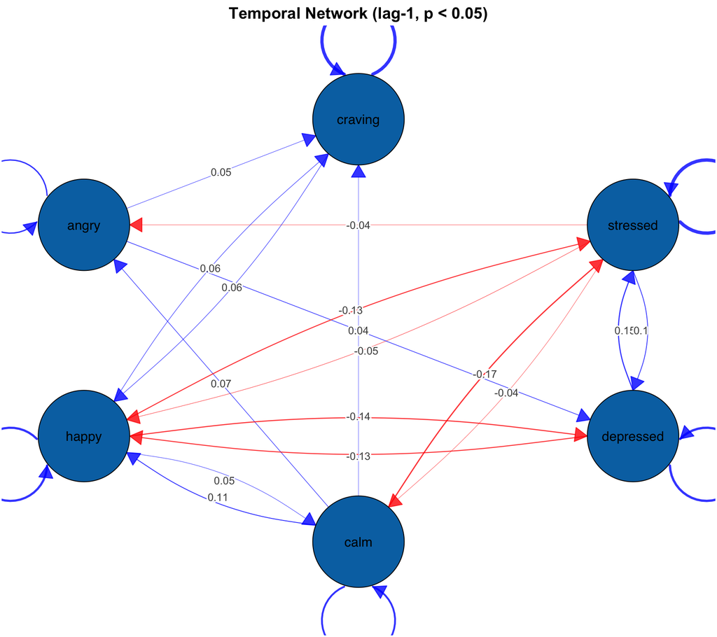

```r
B <- fit$temporal
sig_mask <- matrix(TRUE, nrow(B), ncol(B))
for (k in seq_along(vars_real)) {
  sig_mask[k, ] <- fit$coefs[[k]]$p < 0.05
}
B_sig <- B * sig_mask

cograph::splot(
  B_sig,
  directed = TRUE,
  title = "Temporal Network (lag-1, p < 0.05)",
  edge_labels = TRUE,
  node_size = 10,
  theme = "colorblind"
)
```

**Interpretation**: All six variables show significant autoregressive effects (diagonal), with craving (0.46) and stressed (0.48) being the most persistent. Key cross-lagged paths include stressed $\rightarrow$ depressed (+0.15), stressed $\rightarrow$ calm ($-$0.17), and depressed $\rightarrow$ happy ($-$0.14).

## 6.3 Contemporaneous Network

Undirected partial correlations among within-person OLS residuals, estimated via EBIC-GLASSO ($\gamma = 0.5$).

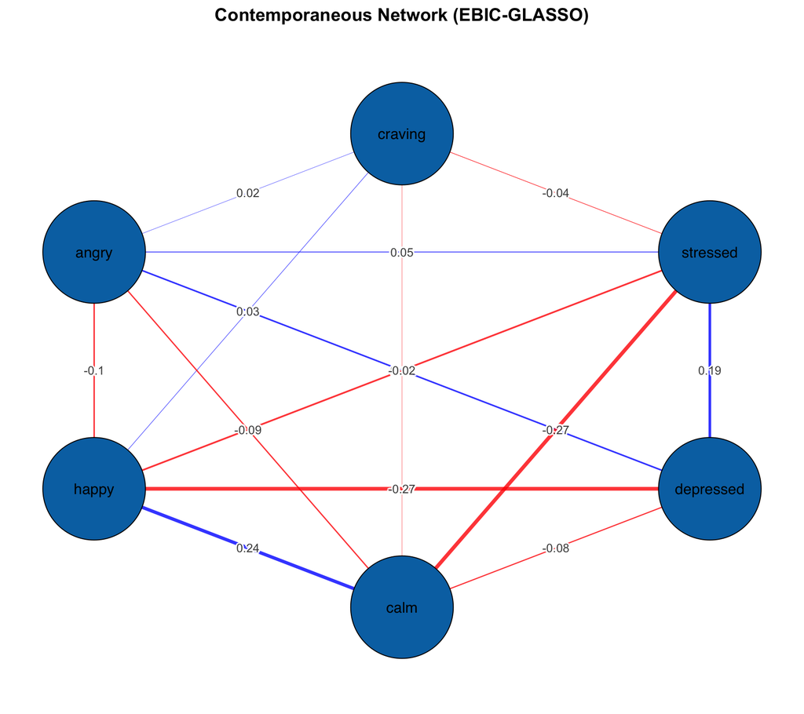

```r
cograph::splot(
  fit$contemporaneous,
  directed = FALSE,
  title = "Contemporaneous Network (EBIC-GLASSO)",
  edge_labels = TRUE,
  node_size = 10,
  theme = "colorblind"
)
```

## 6.4 Between-Subjects Network

Undirected partial correlations among person means, estimated via EBIC-GLASSO ($\gamma = 0.5$).

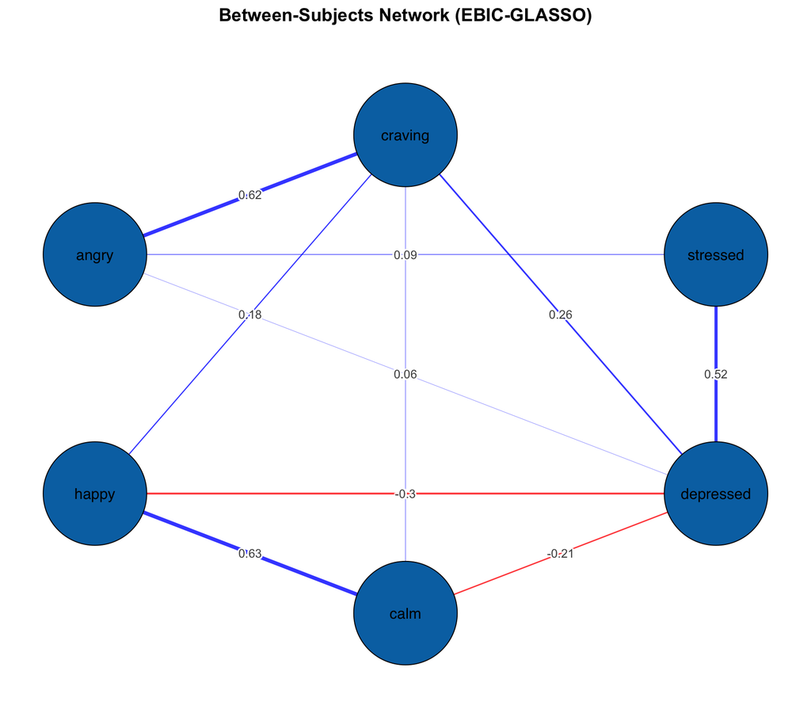

```r
cograph::splot(
  fit$between,
  directed = FALSE,
  title = "Between-Subjects Network (EBIC-GLASSO)",
  edge_labels = TRUE,
  node_size = 10,
  theme = "colorblind"
)
```

**Interpretation**: At the between-person level, the strongest associations are calm–happy (+0.63), angry–craving (+0.62), and stressed–depressed (+0.52). People who are generally angrier also tend to have higher average craving.

## 6.5 All Three Networks

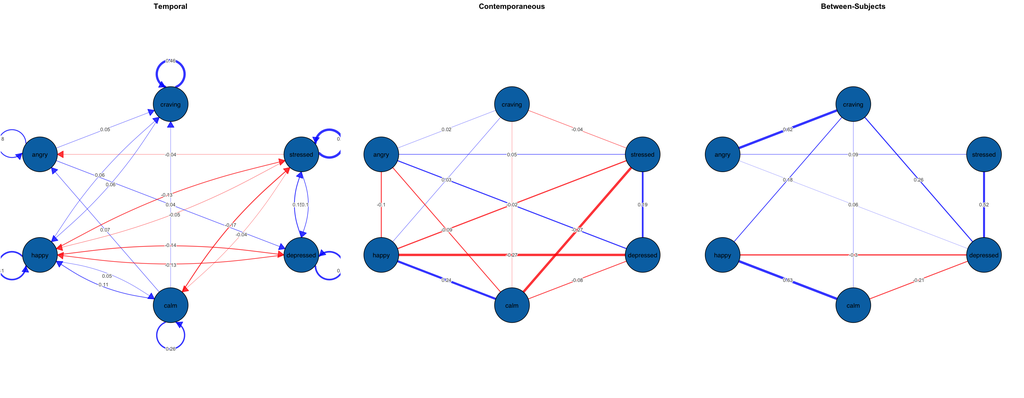

```r
old_par <- par(mfrow = c(1, 3), mar = c(2, 1, 3, 1))

cograph::splot(
  B_sig,
  directed = TRUE,
  title = "Temporal",
  edge_labels = TRUE,
  node_size = 8,
  theme = "colorblind"
)

cograph::splot(
  fit$contemporaneous,
  directed = FALSE,
  title = "Contemporaneous",
  edge_labels = TRUE,
  node_size = 8,
  theme = "colorblind"
)

cograph::splot(
  fit$between,
  directed = FALSE,
  title = "Between-Subjects",
  edge_labels = TRUE,
  node_size = 8,
  theme = "colorblind"
)
```

```r
par(old_par)
```

# 7. Architecture

## 7.1 Internal Functions

| Function | Purpose |
| --- | --- |
| `.mlvar_prepare_data()` | Sort, coerce, drop NAs |
| `.mlvar_build_lag_pairs()` | Vectorized lag-pair construction |
| `.mlvar_within_center()` | Person-mean centering + optional standardization |
| `.mlvar_temporal_ols()` | OLS per outcome with df-corrected inference |
| `.mlvar_contemporaneous()` | EBIC-GLASSO on residual correlations |
| `.mlvar_between()` | EBIC-GLASSO on person-mean correlations |

## 7.2 Reused Functions

| Function | Source | Used in |
| --- | --- | --- |
| `.compute_lambda_path()` | `R/estimators.R` | Contemporaneous, Between |
| `.select_ebic()` | `R/estimators.R` | Contemporaneous, Between |
| `.precision_to_pcor()` | `R/estimators.R` | Contemporaneous, Between |

## 7.3 Dependencies

Zero new dependencies. Uses only:

- **base R**: `ave`, `complete.cases`, `order`, `crossprod`, `solve`
- **stats** (already imported): `lm.fit`, `cor`, `sd`, `pt`, `qt`, `aggregate`, `var`
- **glasso** (already in Imports): via the existing GLASSO pipeline

# 8. Test Suite

| Category | Tests | Description |
| --- | --- | --- |
| Input validation | 8 | Bad data, missing columns, too few subjects |
| Lag-pair construction | 8 | Day boundaries, beep gaps, cross-person exclusion |
| Within-centering | 5 | Zero person means, standardization, both Y and X |
| Temporal OLS | 10 | Dimensions, direction, df correction, CI, p-values |
| Contemporaneous | 6 | Symmetry, diagonal, range, sparsity, gamma effect |
| Between-subjects | 6 | Symmetry, diagonal, range, guard for few subjects |
| S3 methods | 4 | Class, fields, print, summary |
| simulate_data(“mlvar”) | 6 | Columns, attributes, reproducibility, round-trip |
| Integration/recovery | 3 | Known B recovery, end-to-end, no day/beep |
| **mlVAR equivalence** | **6** | **25 seeds: exact B, p-values, residuals, significance** |

All 1522 tests in the full suite pass with 0 failures and 0 warnings.

# 9. Summary Table

[output not shown]

# References